# Risk Factor Analysis

## Outcome Variable

**Outcome Variable:** ever_stunted

## Predictor Variables

**Intervention Variable:** lag_WHZ_quart

**Adjustment Set:**

- arm
- sex
- brthmon
- W_mage
- meducyrs
- feducyrs
- hhwealth_quart
- hdlvry
- month
- W_parity
- delta_W_mage
- delta_meducyrs
- delta_feducyrs
- delta_hhwealth_quart
- delta_hdlvry
- delta_month
- delta_W_parity

## Stratifying Variables

The analysis was stratified on these variable(s):

- agecat
- studyid
- country

## Data Summary

| agecat | studyid | country | lag_WHZ_quart | ever_stunted | n_cell | n |
| --- | --- | --- | --- | --- | --- | --- |
| 3-6 months | CMC-V-BCS-2002 | INDIA | 1 | 0 | 34 | 294 |
| 3-6 months | CMC-V-BCS-2002 | INDIA | 1 | 1 | 20 | 294 |
| 3-6 months | CMC-V-BCS-2002 | INDIA | 2 | 0 | 85 | 294 |
| 3-6 months | CMC-V-BCS-2002 | INDIA | 2 | 1 | 48 | 294 |
| 3-6 months | CMC-V-BCS-2002 | INDIA | 3 | 0 | 72 | 294 |
| 3-6 months | CMC-V-BCS-2002 | INDIA | 3 | 1 | 22 | 294 |
| 3-6 months | CMC-V-BCS-2002 | INDIA | 4 | 0 | 9 | 294 |
| 3-6 months | CMC-V-BCS-2002 | INDIA | 4 | 1 | 4 | 294 |
| 3-6 months | CMIN | BANGLADESH | 1 | 0 | 40 | 159 |
| 3-6 months | CMIN | BANGLADESH | 1 | 1 | 15 | 159 |
| 3-6 months | CMIN | BANGLADESH | 2 | 0 | 43 | 159 |
| 3-6 months | CMIN | BANGLADESH | 2 | 1 | 11 | 159 |
| 3-6 months | CMIN | BANGLADESH | 3 | 0 | 25 | 159 |
| 3-6 months | CMIN | BANGLADESH | 3 | 1 | 9 | 159 |
| 3-6 months | CMIN | BANGLADESH | 4 | 0 | 13 | 159 |
| 3-6 months | CMIN | BANGLADESH | 4 | 1 | 3 | 159 |
| 3-6 months | CONTENT | PERU | 1 | 0 | 0 | 4 |
| 3-6 months | CONTENT | PERU | 1 | 1 | 0 | 4 |
| 3-6 months | CONTENT | PERU | 2 | 0 | 1 | 4 |
| 3-6 months | CONTENT | PERU | 2 | 1 | 0 | 4 |
| 3-6 months | CONTENT | PERU | 3 | 0 | 3 | 4 |
| 3-6 months | CONTENT | PERU | 3 | 1 | 0 | 4 |
| 3-6 months | CONTENT | PERU | 4 | 0 | 0 | 4 |
| 3-6 months | CONTENT | PERU | 4 | 1 | 0 | 4 |
| 3-6 months | EE | PAKISTAN | 1 | 0 | 1 | 5 |
| 3-6 months | EE | PAKISTAN | 1 | 1 | 1 | 5 |
| 3-6 months | EE | PAKISTAN | 2 | 0 | 1 | 5 |
| 3-6 months | EE | PAKISTAN | 2 | 1 | 2 | 5 |
| 3-6 months | EE | PAKISTAN | 3 | 0 | 0 | 5 |
| 3-6 months | EE | PAKISTAN | 3 | 1 | 0 | 5 |

[output cut: 850 more lines]

The following strata were considered:

- agecat: 12-15 months, studyid: CMC-V-BCS-2002, country: INDIA
- agecat: 12-15 months, studyid: CMIN, country: BANGLADESH
- agecat: 12-15 months, studyid: EE, country: PAKISTAN
- agecat: 12-15 months, studyid: GMS-Nepal, country: NEPAL
- agecat: 12-15 months, studyid: Guatemala BSC, country: GUATEMALA
- agecat: 12-15 months, studyid: IRC, country: INDIA
- agecat: 12-15 months, studyid: Keneba, country: GAMBIA
- agecat: 12-15 months, studyid: MAL-ED, country: BRAZIL
- agecat: 12-15 months, studyid: MAL-ED, country: INDIA
- agecat: 12-15 months, studyid: MAL-ED, country: NEPAL
- agecat: 12-15 months, studyid: MAL-ED, country: PERU
- agecat: 12-15 months, studyid: MAL-ED, country: SOUTH AFRICA
- agecat: 12-15 months, studyid: MAL-ED, country: TANZANIA, UNITED REPUBLIC OF
- agecat: 12-15 months, studyid: PROVIDE, country: BANGLADESH
- agecat: 12-15 months, studyid: ResPak, country: PAKISTAN
- agecat: 12-15 months, studyid: TanzaniaChild2, country: TANZANIA, UNITED REPUBLIC OF
- agecat: 15-18 months, studyid: CMC-V-BCS-2002, country: INDIA
- agecat: 15-18 months, studyid: CMIN, country: BANGLADESH
- agecat: 15-18 months, studyid: CONTENT, country: PERU
- agecat: 15-18 months, studyid: EE, country: PAKISTAN
- agecat: 15-18 months, studyid: GMS-Nepal, country: NEPAL
- agecat: 15-18 months, studyid: Guatemala BSC, country: GUATEMALA
- agecat: 15-18 months, studyid: IRC, country: INDIA
- agecat: 15-18 months, studyid: Keneba, country: GAMBIA
- agecat: 15-18 months, studyid: MAL-ED, country: BRAZIL
- agecat: 15-18 months, studyid: MAL-ED, country: INDIA
- agecat: 15-18 months, studyid: MAL-ED, country: NEPAL
- agecat: 15-18 months, studyid: MAL-ED, country: PERU
- agecat: 15-18 months, studyid: MAL-ED, country: SOUTH AFRICA
- agecat: 15-18 months, studyid: MAL-ED, country: TANZANIA, UNITED REPUBLIC OF
- agecat: 15-18 months, studyid: PROVIDE, country: BANGLADESH
- agecat: 15-18 months, studyid: ResPak, country: PAKISTAN
- agecat: 15-18 months, studyid: TanzaniaChild2, country: TANZANIA, UNITED REPUBLIC OF
- agecat: 18-21 months, studyid: CMC-V-BCS-2002, country: INDIA
- agecat: 18-21 months, studyid: CMIN, country: BANGLADESH
- agecat: 18-21 months, studyid: EE, country: PAKISTAN
- agecat: 18-21 months, studyid: GMS-Nepal, country: NEPAL
- agecat: 18-21 months, studyid: IRC, country: INDIA
- agecat: 18-21 months, studyid: Keneba, country: GAMBIA
- agecat: 18-21 months, studyid: MAL-ED, country: BRAZIL
- agecat: 18-21 months, studyid: MAL-ED, country: INDIA
- agecat: 18-21 months, studyid: MAL-ED, country: NEPAL
- agecat: 18-21 months, studyid: MAL-ED, country: PERU
- agecat: 18-21 months, studyid: MAL-ED, country: SOUTH AFRICA
- agecat: 18-21 months, studyid: MAL-ED, country: TANZANIA, UNITED REPUBLIC OF
- agecat: 18-21 months, studyid: PROVIDE, country: BANGLADESH
- agecat: 18-21 months, studyid: TanzaniaChild2, country: TANZANIA, UNITED REPUBLIC OF
- agecat: 21-24 months, studyid: CMC-V-BCS-2002, country: INDIA
- agecat: 21-24 months, studyid: CMIN, country: BANGLADESH
- agecat: 21-24 months, studyid: GMS-Nepal, country: NEPAL
- agecat: 21-24 months, studyid: IRC, country: INDIA
- agecat: 21-24 months, studyid: Keneba, country: GAMBIA
- agecat: 21-24 months, studyid: MAL-ED, country: BRAZIL
- agecat: 21-24 months, studyid: MAL-ED, country: INDIA
- agecat: 21-24 months, studyid: MAL-ED, country: NEPAL
- agecat: 21-24 months, studyid: MAL-ED, country: PERU
- agecat: 21-24 months, studyid: MAL-ED, country: SOUTH AFRICA
- agecat: 21-24 months, studyid: MAL-ED, country: TANZANIA, UNITED REPUBLIC OF
- agecat: 21-24 months, studyid: PROVIDE, country: BANGLADESH
- agecat: 21-24 months, studyid: TanzaniaChild2, country: TANZANIA, UNITED REPUBLIC OF
- agecat: 3-6 months, studyid: CMC-V-BCS-2002, country: INDIA
- agecat: 3-6 months, studyid: CMIN, country: BANGLADESH
- agecat: 3-6 months, studyid: CONTENT, country: PERU
- agecat: 3-6 months, studyid: EE, country: PAKISTAN
- agecat: 3-6 months, studyid: GMS-Nepal, country: NEPAL
- agecat: 3-6 months, studyid: Guatemala BSC, country: GUATEMALA
- agecat: 3-6 months, studyid: IRC, country: INDIA
- agecat: 3-6 months, studyid: Keneba, country: GAMBIA
- agecat: 3-6 months, studyid: MAL-ED, country: INDIA
- agecat: 3-6 months, studyid: MAL-ED, country: NEPAL
- agecat: 3-6 months, studyid: MAL-ED, country: PERU
- agecat: 3-6 months, studyid: MAL-ED, country: SOUTH AFRICA
- agecat: 3-6 months, studyid: MAL-ED, country: TANZANIA, UNITED REPUBLIC OF
- agecat: 3-6 months, studyid: PROVIDE, country: BANGLADESH
- agecat: 3-6 months, studyid: ResPak, country: PAKISTAN
- agecat: 3-6 months, studyid: TanzaniaChild2, country: TANZANIA, UNITED REPUBLIC OF
- agecat: 6-9 months, studyid: CMC-V-BCS-2002, country: INDIA
- agecat: 6-9 months, studyid: CMIN, country: BANGLADESH
- agecat: 6-9 months, studyid: CONTENT, country: PERU
- agecat: 6-9 months, studyid: EE, country: PAKISTAN
- agecat: 6-9 months, studyid: GMS-Nepal, country: NEPAL
- agecat: 6-9 months, studyid: Guatemala BSC, country: GUATEMALA
- agecat: 6-9 months, studyid: IRC, country: INDIA
- agecat: 6-9 months, studyid: Keneba, country: GAMBIA
- agecat: 6-9 months, studyid: MAL-ED, country: BRAZIL
- agecat: 6-9 months, studyid: MAL-ED, country: INDIA
- agecat: 6-9 months, studyid: MAL-ED, country: NEPAL
- agecat: 6-9 months, studyid: MAL-ED, country: PERU
- agecat: 6-9 months, studyid: MAL-ED, country: SOUTH AFRICA
- agecat: 6-9 months, studyid: MAL-ED, country: TANZANIA, UNITED REPUBLIC OF
- agecat: 6-9 months, studyid: PROVIDE, country: BANGLADESH
- agecat: 6-9 months, studyid: ResPak, country: PAKISTAN
- agecat: 6-9 months, studyid: TanzaniaChild2, country: TANZANIA, UNITED REPUBLIC OF
- agecat: 9-12 months, studyid: CMC-V-BCS-2002, country: INDIA
- agecat: 9-12 months, studyid: CMIN, country: BANGLADESH
- agecat: 9-12 months, studyid: CONTENT, country: PERU
- agecat: 9-12 months, studyid: EE, country: PAKISTAN
- agecat: 9-12 months, studyid: GMS-Nepal, country: NEPAL
- agecat: 9-12 months, studyid: Guatemala BSC, country: GUATEMALA
- agecat: 9-12 months, studyid: IRC, country: INDIA
- agecat: 9-12 months, studyid: Keneba, country: GAMBIA
- agecat: 9-12 months, studyid: MAL-ED, country: BRAZIL
- agecat: 9-12 months, studyid: MAL-ED, country: INDIA
- agecat: 9-12 months, studyid: MAL-ED, country: NEPAL
- agecat: 9-12 months, studyid: MAL-ED, country: PERU
- agecat: 9-12 months, studyid: MAL-ED, country: SOUTH AFRICA
- agecat: 9-12 months, studyid: MAL-ED, country: TANZANIA, UNITED REPUBLIC OF
- agecat: 9-12 months, studyid: PROVIDE, country: BANGLADESH
- agecat: 9-12 months, studyid: ResPak, country: PAKISTAN
- agecat: 9-12 months, studyid: TanzaniaChild2, country: TANZANIA, UNITED REPUBLIC OF

### Dropped Strata

Some strata were dropped due to rare outcomes:

- agecat: 3-6 months, studyid: CMC-V-BCS-2002, country: INDIA
- agecat: 3-6 months, studyid: CMIN, country: BANGLADESH
- agecat: 3-6 months, studyid: CONTENT, country: PERU
- agecat: 3-6 months, studyid: EE, country: PAKISTAN
- agecat: 3-6 months, studyid: GMS-Nepal, country: NEPAL
- agecat: 3-6 months, studyid: Guatemala BSC, country: GUATEMALA
- agecat: 3-6 months, studyid: IRC, country: INDIA
- agecat: 3-6 months, studyid: MAL-ED, country: INDIA
- agecat: 3-6 months, studyid: MAL-ED, country: NEPAL
- agecat: 3-6 months, studyid: MAL-ED, country: PERU
- agecat: 3-6 months, studyid: MAL-ED, country: SOUTH AFRICA
- agecat: 3-6 months, studyid: MAL-ED, country: TANZANIA, UNITED REPUBLIC OF
- agecat: 6-9 months, studyid: CMC-V-BCS-2002, country: INDIA
- agecat: 6-9 months, studyid: CMIN, country: BANGLADESH
- agecat: 6-9 months, studyid: CONTENT, country: PERU
- agecat: 6-9 months, studyid: EE, country: PAKISTAN
- agecat: 6-9 months, studyid: GMS-Nepal, country: NEPAL
- agecat: 6-9 months, studyid: IRC, country: INDIA
- agecat: 6-9 months, studyid: MAL-ED, country: BRAZIL
- agecat: 6-9 months, studyid: MAL-ED, country: INDIA
- agecat: 6-9 months, studyid: MAL-ED, country: NEPAL
- agecat: 6-9 months, studyid: MAL-ED, country: PERU
- agecat: 6-9 months, studyid: MAL-ED, country: SOUTH AFRICA
- agecat: 6-9 months, studyid: MAL-ED, country: TANZANIA, UNITED REPUBLIC OF
- agecat: 6-9 months, studyid: PROVIDE, country: BANGLADESH
- agecat: 6-9 months, studyid: ResPak, country: PAKISTAN
- agecat: 9-12 months, studyid: CMC-V-BCS-2002, country: INDIA
- agecat: 9-12 months, studyid: CMIN, country: BANGLADESH
- agecat: 9-12 months, studyid: CONTENT, country: PERU
- agecat: 9-12 months, studyid: EE, country: PAKISTAN
- agecat: 9-12 months, studyid: GMS-Nepal, country: NEPAL
- agecat: 9-12 months, studyid: IRC, country: INDIA
- agecat: 9-12 months, studyid: MAL-ED, country: BRAZIL
- agecat: 9-12 months, studyid: MAL-ED, country: INDIA
- agecat: 9-12 months, studyid: MAL-ED, country: NEPAL
- agecat: 9-12 months, studyid: MAL-ED, country: PERU
- agecat: 9-12 months, studyid: MAL-ED, country: SOUTH AFRICA
- agecat: 9-12 months, studyid: MAL-ED, country: TANZANIA, UNITED REPUBLIC OF
- agecat: 9-12 months, studyid: PROVIDE, country: BANGLADESH
- agecat: 9-12 months, studyid: ResPak, country: PAKISTAN
- agecat: 12-15 months, studyid: CMC-V-BCS-2002, country: INDIA
- agecat: 12-15 months, studyid: CMIN, country: BANGLADESH
- agecat: 12-15 months, studyid: EE, country: PAKISTAN
- agecat: 12-15 months, studyid: GMS-Nepal, country: NEPAL
- agecat: 12-15 months, studyid: Guatemala BSC, country: GUATEMALA
- agecat: 12-15 months, studyid: IRC, country: INDIA
- agecat: 12-15 months, studyid: MAL-ED, country: BRAZIL
- agecat: 12-15 months, studyid: MAL-ED, country: INDIA
- agecat: 12-15 months, studyid: MAL-ED, country: NEPAL
- agecat: 12-15 months, studyid: MAL-ED, country: PERU
- agecat: 12-15 months, studyid: MAL-ED, country: SOUTH AFRICA
- agecat: 12-15 months, studyid: MAL-ED, country: TANZANIA, UNITED REPUBLIC OF
- agecat: 12-15 months, studyid: PROVIDE, country: BANGLADESH
- agecat: 12-15 months, studyid: ResPak, country: PAKISTAN
- agecat: 15-18 months, studyid: CMC-V-BCS-2002, country: INDIA
- agecat: 15-18 months, studyid: CMIN, country: BANGLADESH
- agecat: 15-18 months, studyid: CONTENT, country: PERU
- agecat: 15-18 months, studyid: EE, country: PAKISTAN
- agecat: 15-18 months, studyid: GMS-Nepal, country: NEPAL
- agecat: 15-18 months, studyid: Guatemala BSC, country: GUATEMALA
- agecat: 15-18 months, studyid: IRC, country: INDIA
- agecat: 15-18 months, studyid: MAL-ED, country: BRAZIL
- agecat: 15-18 months, studyid: MAL-ED, country: INDIA
- agecat: 15-18 months, studyid: MAL-ED, country: NEPAL
- agecat: 15-18 months, studyid: MAL-ED, country: PERU
- agecat: 15-18 months, studyid: MAL-ED, country: SOUTH AFRICA
- agecat: 15-18 months, studyid: MAL-ED, country: TANZANIA, UNITED REPUBLIC OF
- agecat: 15-18 months, studyid: PROVIDE, country: BANGLADESH
- agecat: 15-18 months, studyid: ResPak, country: PAKISTAN
- agecat: 18-21 months, studyid: CMC-V-BCS-2002, country: INDIA
- agecat: 18-21 months, studyid: CMIN, country: BANGLADESH
- agecat: 18-21 months, studyid: EE, country: PAKISTAN
- agecat: 18-21 months, studyid: GMS-Nepal, country: NEPAL
- agecat: 18-21 months, studyid: IRC, country: INDIA
- agecat: 18-21 months, studyid: MAL-ED, country: BRAZIL
- agecat: 18-21 months, studyid: MAL-ED, country: INDIA
- agecat: 18-21 months, studyid: MAL-ED, country: NEPAL
- agecat: 18-21 months, studyid: MAL-ED, country: PERU
- agecat: 18-21 months, studyid: MAL-ED, country: SOUTH AFRICA
- agecat: 18-21 months, studyid: MAL-ED, country: TANZANIA, UNITED REPUBLIC OF
- agecat: 18-21 months, studyid: PROVIDE, country: BANGLADESH
- agecat: 18-21 months, studyid: TanzaniaChild2, country: TANZANIA, UNITED REPUBLIC OF
- agecat: 21-24 months, studyid: CMC-V-BCS-2002, country: INDIA
- agecat: 21-24 months, studyid: CMIN, country: BANGLADESH
- agecat: 21-24 months, studyid: GMS-Nepal, country: NEPAL
- agecat: 21-24 months, studyid: IRC, country: INDIA
- agecat: 21-24 months, studyid: MAL-ED, country: BRAZIL
- agecat: 21-24 months, studyid: MAL-ED, country: INDIA
- agecat: 21-24 months, studyid: MAL-ED, country: NEPAL
- agecat: 21-24 months, studyid: MAL-ED, country: PERU
- agecat: 21-24 months, studyid: MAL-ED, country: SOUTH AFRICA
- agecat: 21-24 months, studyid: MAL-ED, country: TANZANIA, UNITED REPUBLIC OF
- agecat: 21-24 months, studyid: PROVIDE, country: BANGLADESH
- agecat: 21-24 months, studyid: TanzaniaChild2, country: TANZANIA, UNITED REPUBLIC OF

## Methods Detail

We’re interested in the causal parameters $E[Y_a]$ for all values of $a \in \mathcal{A}$. These parameters represent the mean outcome if, possibly contrary to fact, we intervened to set all units to have $A=a$. Under the randomization and positivity assumptions, these are identified by the statistical parameters $\psi_a=E_W[E_{Y|A,W}(Y|A=a,W)]$. In addition, we’re interested in the mean of $Y$, $E[Y]$ under no intervention (the observed mean). We will estimate these parameters by using SuperLearner to fit the relevant likelihood factors – $E_{Y|A,W}(Y|A=a,W)$ and $p(A=a|W)$, and then updating our likelihood fit using a joint TMLE.

For unadjusted analyses ($W=\{\}$), initial likelihoods were estimated using Lrnr_glm to estimate the simple $E(Y|A)$ and Lrnr_mean to estimate $p(A)$. For adjusted analyses, a small library containing Lrnr_glmnet, Lrnr_xgboost, and Lrnr_mean was used.

Having estimated these parameters, we will then use the delta method to estimate relative risks and attributable risks relative to a prespecified baseline level of $A$.

# Results Detail

## Results Plots

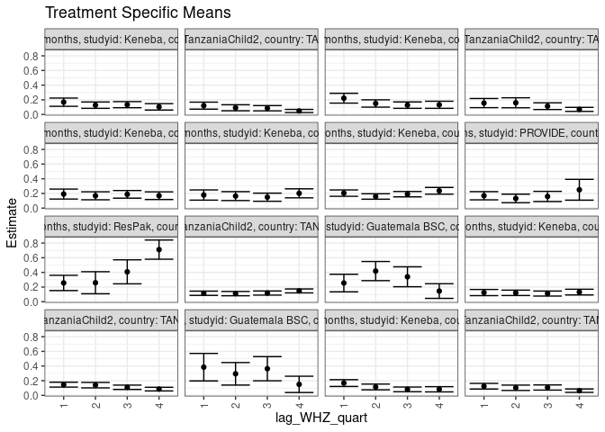

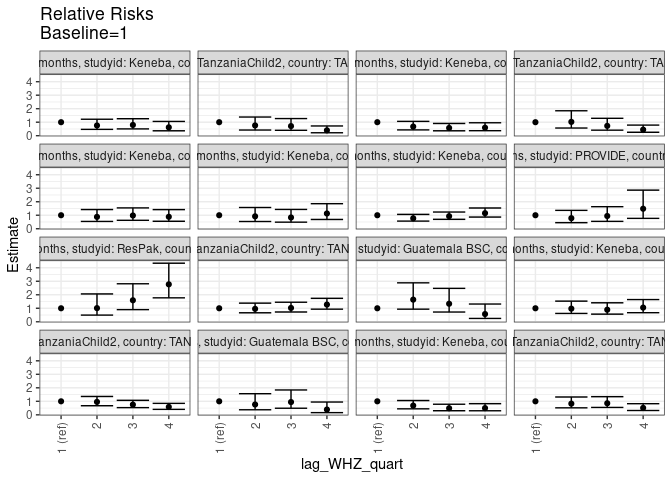

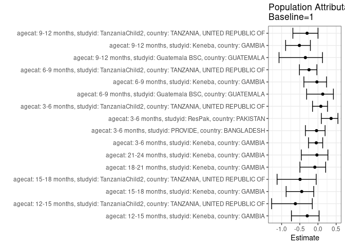

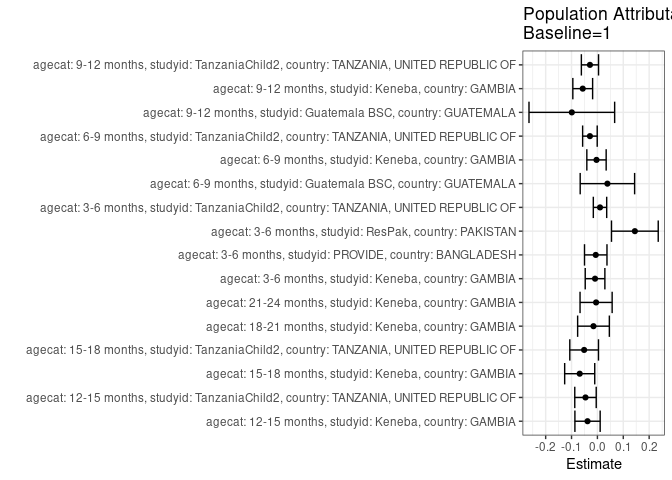

## Results Table

### Parameter: TSM

| agecat | studyid | country | intervention_level | baseline_level | estimate | ci_lower | ci_upper |
| --- | --- | --- | --- | --- | --- | --- | --- |
| 3-6 months | Keneba | GAMBIA | 1 | NA | 0.2046634 | 0.1613142 | 0.2480125 |
| 3-6 months | Keneba | GAMBIA | 2 | NA | 0.1584829 | 0.1213371 | 0.1956286 |
| 3-6 months | Keneba | GAMBIA | 3 | NA | 0.1899829 | 0.1534376 | 0.2265283 |
| 3-6 months | Keneba | GAMBIA | 4 | NA | 0.2358559 | 0.1899751 | 0.2817367 |
| 3-6 months | PROVIDE | BANGLADESH | 1 | NA | 0.1686047 | 0.1125887 | 0.2246206 |
| 3-6 months | PROVIDE | BANGLADESH | 2 | NA | 0.1317829 | 0.0733461 | 0.1902198 |
| 3-6 months | PROVIDE | BANGLADESH | 3 | NA | 0.1588785 | 0.0895347 | 0.2282223 |
| 3-6 months | PROVIDE | BANGLADESH | 4 | NA | 0.2500000 | 0.1083922 | 0.3916078 |
| 3-6 months | ResPak | PAKISTAN | 1 | NA | 0.2562807 | 0.1520483 | 0.3605132 |
| 3-6 months | ResPak | PAKISTAN | 2 | NA | 0.2591163 | 0.1088248 | 0.4094078 |
| 3-6 months | ResPak | PAKISTAN | 3 | NA | 0.4079691 | 0.2442330 | 0.5717051 |
| 3-6 months | ResPak | PAKISTAN | 4 | NA | 0.7107214 | 0.5798173 | 0.8416256 |
| 3-6 months | TanzaniaChild2 | TANZANIA, UNITED REPUBLIC OF | 1 | NA | 0.1157969 | 0.0867465 | 0.1448473 |
| 3-6 months | TanzaniaChild2 | TANZANIA, UNITED REPUBLIC OF | 2 | NA | 0.1109071 | 0.0813338 | 0.1404803 |
| 3-6 months | TanzaniaChild2 | TANZANIA, UNITED REPUBLIC OF | 3 | NA | 0.1185373 | 0.0900821 | 0.1469925 |
| 3-6 months | TanzaniaChild2 | TANZANIA, UNITED REPUBLIC OF | 4 | NA | 0.1475325 | 0.1207926 | 0.1742724 |
| 6-9 months | Guatemala BSC | GUATEMALA | 1 | NA | 0.2549020 | 0.1349964 | 0.3748075 |
| 6-9 months | Guatemala BSC | GUATEMALA | 2 | NA | 0.4181818 | 0.2874967 | 0.5488669 |
| 6-9 months | Guatemala BSC | GUATEMALA | 3 | NA | 0.3404255 | 0.2046176 | 0.4762335 |
| 6-9 months | Guatemala BSC | GUATEMALA | 4 | NA | 0.1458333 | 0.0457388 | 0.2459278 |
| 6-9 months | Keneba | GAMBIA | 1 | NA | 0.1250501 | 0.0829499 | 0.1671502 |
| 6-9 months | Keneba | GAMBIA | 2 | NA | 0.1214653 | 0.0844159 | 0.1585147 |
| 6-9 months | Keneba | GAMBIA | 3 | NA | 0.1115204 | 0.0773524 | 0.1456885 |
| 6-9 months | Keneba | GAMBIA | 4 | NA | 0.1314546 | 0.0925164 | 0.1703929 |
| 6-9 months | TanzaniaChild2 | TANZANIA, UNITED REPUBLIC OF | 1 | NA | 0.1462520 | 0.1127594 | 0.1797446 |
| 6-9 months | TanzaniaChild2 | TANZANIA, UNITED REPUBLIC OF | 2 | NA | 0.1398263 | 0.1025967 | 0.1770559 |
| 6-9 months | TanzaniaChild2 | TANZANIA, UNITED REPUBLIC OF | 3 | NA | 0.1102983 | 0.0807845 | 0.1398120 |
| 6-9 months | TanzaniaChild2 | TANZANIA, UNITED REPUBLIC OF | 4 | NA | 0.0856625 | 0.0607056 | 0.1106194 |
| 9-12 months | Guatemala BSC | GUATEMALA | 1 | NA | 0.3846154 | 0.1969056 | 0.5723252 |
| 9-12 months | Guatemala BSC | GUATEMALA | 2 | NA | 0.2941176 | 0.1403821 | 0.4478532 |
| 9-12 months | Guatemala BSC | GUATEMALA | 3 | NA | 0.3636364 | 0.1988898 | 0.5283829 |
| 9-12 months | Guatemala BSC | GUATEMALA | 4 | NA | 0.1500000 | 0.0389261 | 0.2610739 |
| 9-12 months | Keneba | GAMBIA | 1 | NA | 0.1677507 | 0.1215302 | 0.2139712 |
| 9-12 months | Keneba | GAMBIA | 2 | NA | 0.1148002 | 0.0757657 | 0.1538347 |
| 9-12 months | Keneba | GAMBIA | 3 | NA | 0.0816947 | 0.0497607 | 0.1136287 |
| 9-12 months | Keneba | GAMBIA | 4 | NA | 0.0833032 | 0.0476965 | 0.1189098 |
| 9-12 months | TanzaniaChild2 | TANZANIA, UNITED REPUBLIC OF | 1 | NA | 0.1250858 | 0.0863486 | 0.1638230 |
| 9-12 months | TanzaniaChild2 | TANZANIA, UNITED REPUBLIC OF | 2 | NA | 0.1034454 | 0.0671984 | 0.1396925 |
| 9-12 months | TanzaniaChild2 | TANZANIA, UNITED REPUBLIC OF | 3 | NA | 0.1070880 | 0.0719142 | 0.1422619 |
| 9-12 months | TanzaniaChild2 | TANZANIA, UNITED REPUBLIC OF | 4 | NA | 0.0640801 | 0.0409536 | 0.0872066 |
| 12-15 months | Keneba | GAMBIA | 1 | NA | 0.1676670 | 0.1116765 | 0.2236574 |
| 12-15 months | Keneba | GAMBIA | 2 | NA | 0.1268187 | 0.0834267 | 0.1702106 |
| 12-15 months | Keneba | GAMBIA | 3 | NA | 0.1334098 | 0.0917611 | 0.1750585 |
| 12-15 months | Keneba | GAMBIA | 4 | NA | 0.1038787 | 0.0604367 | 0.1473208 |
| 12-15 months | TanzaniaChild2 | TANZANIA, UNITED REPUBLIC OF | 1 | NA | 0.1201310 | 0.0724820 | 0.1677801 |
| 12-15 months | TanzaniaChild2 | TANZANIA, UNITED REPUBLIC OF | 2 | NA | 0.0913601 | 0.0504314 | 0.1322888 |
| 12-15 months | TanzaniaChild2 | TANZANIA, UNITED REPUBLIC OF | 3 | NA | 0.0854747 | 0.0493988 | 0.1215506 |
| 12-15 months | TanzaniaChild2 | TANZANIA, UNITED REPUBLIC OF | 4 | NA | 0.0476910 | 0.0264719 | 0.0689102 |
| 15-18 months | Keneba | GAMBIA | 1 | NA | 0.2216757 | 0.1547965 | 0.2885548 |
| 15-18 months | Keneba | GAMBIA | 2 | NA | 0.1499395 | 0.0997651 | 0.2001139 |
| 15-18 months | Keneba | GAMBIA | 3 | NA | 0.1272287 | 0.0836489 | 0.1708085 |
| 15-18 months | Keneba | GAMBIA | 4 | NA | 0.1319434 | 0.0835215 | 0.1803654 |
| 15-18 months | TanzaniaChild2 | TANZANIA, UNITED REPUBLIC OF | 1 | NA | 0.1553893 | 0.0926975 | 0.2180811 |
| 15-18 months | TanzaniaChild2 | TANZANIA, UNITED REPUBLIC OF | 2 | NA | 0.1592372 | 0.0907950 | 0.2276794 |
| 15-18 months | TanzaniaChild2 | TANZANIA, UNITED REPUBLIC OF | 3 | NA | 0.1130585 | 0.0672085 | 0.1589085 |
| 15-18 months | TanzaniaChild2 | TANZANIA, UNITED REPUBLIC OF | 4 | NA | 0.0693349 | 0.0418342 | 0.0968356 |
| 18-21 months | Keneba | GAMBIA | 1 | NA | 0.1913557 | 0.1231779 | 0.2595336 |
| 18-21 months | Keneba | GAMBIA | 2 | NA | 0.1679889 | 0.1135412 | 0.2224366 |
| 18-21 months | Keneba | GAMBIA | 3 | NA | 0.1876606 | 0.1354265 | 0.2398947 |
| 18-21 months | Keneba | GAMBIA | 4 | NA | 0.1694217 | 0.1174348 | 0.2214087 |
| 21-24 months | Keneba | GAMBIA | 1 | NA | 0.1782534 | 0.1087263 | 0.2477804 |
| 21-24 months | Keneba | GAMBIA | 2 | NA | 0.1637509 | 0.1030564 | 0.2244455 |
| 21-24 months | Keneba | GAMBIA | 3 | NA | 0.1486802 | 0.0933104 | 0.2040500 |
| 21-24 months | Keneba | GAMBIA | 4 | NA | 0.2012502 | 0.1395964 | 0.2629040 |

### Parameter: E(Y)

| agecat | studyid | country | intervention_level | baseline_level | estimate | ci_lower | ci_upper |
| --- | --- | --- | --- | --- | --- | --- | --- |
| 3-6 months | Keneba | GAMBIA | NA | NA | 0.1955496 | 0.1753565 | 0.2157426 |
| 3-6 months | PROVIDE | BANGLADESH | NA | NA | 0.1621622 | 0.1278379 | 0.1964864 |
| 3-6 months | ResPak | PAKISTAN | NA | NA | 0.4010417 | 0.3315353 | 0.4705480 |
| 3-6 months | TanzaniaChild2 | TANZANIA, UNITED REPUBLIC OF | NA | NA | 0.1258405 | 0.1115904 | 0.1400906 |
| 6-9 months | Guatemala BSC | GUATEMALA | NA | NA | 0.2935323 | 0.2304210 | 0.3566437 |
| 6-9 months | Keneba | GAMBIA | NA | NA | 0.1215278 | 0.1026517 | 0.1404039 |
| 6-9 months | TanzaniaChild2 | TANZANIA, UNITED REPUBLIC OF | NA | NA | 0.1173317 | 0.1019339 | 0.1327295 |
| 9-12 months | Guatemala BSC | GUATEMALA | NA | NA | 0.2857143 | 0.2086482 | 0.3627803 |
| 9-12 months | Keneba | GAMBIA | NA | NA | 0.1110020 | 0.0916955 | 0.1303085 |
| 9-12 months | TanzaniaChild2 | TANZANIA, UNITED REPUBLIC OF | NA | NA | 0.0962733 | 0.0801583 | 0.1123883 |
| 12-15 months | Keneba | GAMBIA | NA | NA | 0.1294964 | 0.1066961 | 0.1522967 |
| 12-15 months | TanzaniaChild2 | TANZANIA, UNITED REPUBLIC OF | NA | NA | 0.0740741 | 0.0573677 | 0.0907805 |
| 15-18 months | Keneba | GAMBIA | NA | NA | 0.1532365 | 0.1275592 | 0.1789138 |
| 15-18 months | TanzaniaChild2 | TANZANIA, UNITED REPUBLIC OF | NA | NA | 0.1041096 | 0.0819400 | 0.1262792 |
| 18-21 months | Keneba | GAMBIA | NA | NA | 0.1762238 | 0.1482767 | 0.2041708 |
| 21-24 months | Keneba | GAMBIA | NA | NA | 0.1731749 | 0.1425899 | 0.2037599 |

### Parameter: RR

| agecat | studyid | country | intervention_level | baseline_level | estimate | ci_lower | ci_upper |
| --- | --- | --- | --- | --- | --- | --- | --- |
| 3-6 months | Keneba | GAMBIA | 1 | 1 | 1.0000000 | 1.0000000 | 1.0000000 |
| 3-6 months | Keneba | GAMBIA | 2 | 1 | 0.7743586 | 0.5646392 | 1.0619724 |
| 3-6 months | Keneba | GAMBIA | 3 | 1 | 0.9282703 | 0.6972994 | 1.2357472 |
| 3-6 months | Keneba | GAMBIA | 4 | 1 | 1.1524090 | 0.8643910 | 1.5363955 |
| 3-6 months | PROVIDE | BANGLADESH | 1 | 1 | 1.0000000 | 1.0000000 | 1.0000000 |
| 3-6 months | PROVIDE | BANGLADESH | 2 | 1 | 0.7816092 | 0.4491106 | 1.3602728 |
| 3-6 months | PROVIDE | BANGLADESH | 3 | 1 | 0.9423139 | 0.5444730 | 1.6308532 |
| 3-6 months | PROVIDE | BANGLADESH | 4 | 1 | 1.4827586 | 0.7689177 | 2.8593087 |
| 3-6 months | ResPak | PAKISTAN | 1 | 1 | 1.0000000 | 1.0000000 | 1.0000000 |
| 3-6 months | ResPak | PAKISTAN | 2 | 1 | 1.0110642 | 0.4956522 | 2.0624360 |
| 3-6 months | ResPak | PAKISTAN | 3 | 1 | 1.5918835 | 0.8999717 | 2.8157472 |
| 3-6 months | ResPak | PAKISTAN | 4 | 1 | 2.7732145 | 1.7729379 | 4.3378388 |
| 3-6 months | TanzaniaChild2 | TANZANIA, UNITED REPUBLIC OF | 1 | 1 | 1.0000000 | 1.0000000 | 1.0000000 |
| 3-6 months | TanzaniaChild2 | TANZANIA, UNITED REPUBLIC OF | 2 | 1 | 0.9577724 | 0.6643193 | 1.3808540 |
| 3-6 months | TanzaniaChild2 | TANZANIA, UNITED REPUBLIC OF | 3 | 1 | 1.0236653 | 0.7234532 | 1.4484566 |
| 3-6 months | TanzaniaChild2 | TANZANIA, UNITED REPUBLIC OF | 4 | 1 | 1.2740625 | 0.9349788 | 1.7361198 |
| 6-9 months | Guatemala BSC | GUATEMALA | 1 | 1 | 1.0000000 | 1.0000000 | 1.0000000 |
| 6-9 months | Guatemala BSC | GUATEMALA | 2 | 1 | 1.6405594 | 0.9326671 | 2.8857406 |
| 6-9 months | Guatemala BSC | GUATEMALA | 3 | 1 | 1.3355155 | 0.7207460 | 2.4746606 |
| 6-9 months | Guatemala BSC | GUATEMALA | 4 | 1 | 0.5721154 | 0.2489505 | 1.3147835 |
| 6-9 months | Keneba | GAMBIA | 1 | 1 | 1.0000000 | 1.0000000 | 1.0000000 |
| 6-9 months | Keneba | GAMBIA | 2 | 1 | 0.9713336 | 0.6168115 | 1.5296229 |
| 6-9 months | Keneba | GAMBIA | 3 | 1 | 0.8918064 | 0.5657784 | 1.4057071 |
| 6-9 months | Keneba | GAMBIA | 4 | 1 | 1.0512160 | 0.6714344 | 1.6458124 |
| 6-9 months | TanzaniaChild2 | TANZANIA, UNITED REPUBLIC OF | 1 | 1 | 1.0000000 | 1.0000000 | 1.0000000 |
| 6-9 months | TanzaniaChild2 | TANZANIA, UNITED REPUBLIC OF | 2 | 1 | 0.9560644 | 0.6730724 | 1.3580398 |
| 6-9 months | TanzaniaChild2 | TANZANIA, UNITED REPUBLIC OF | 3 | 1 | 0.7541659 | 0.5303384 | 1.0724592 |
| 6-9 months | TanzaniaChild2 | TANZANIA, UNITED REPUBLIC OF | 4 | 1 | 0.5857186 | 0.4041189 | 0.8489241 |
| 9-12 months | Guatemala BSC | GUATEMALA | 1 | 1 | 1.0000000 | 1.0000000 | 1.0000000 |
| 9-12 months | Guatemala BSC | GUATEMALA | 2 | 1 | 0.7647059 | 0.3740412 | 1.5633977 |
| 9-12 months | Guatemala BSC | GUATEMALA | 3 | 1 | 0.9454545 | 0.4857766 | 1.8401139 |
| 9-12 months | Guatemala BSC | GUATEMALA | 4 | 1 | 0.3900000 | 0.1606597 | 0.9467217 |
| 9-12 months | Keneba | GAMBIA | 1 | 1 | 1.0000000 | 1.0000000 | 1.0000000 |
| 9-12 months | Keneba | GAMBIA | 2 | 1 | 0.6843500 | 0.4426697 | 1.0579782 |
| 9-12 months | Keneba | GAMBIA | 3 | 1 | 0.4870007 | 0.3021390 | 0.7849690 |
| 9-12 months | Keneba | GAMBIA | 4 | 1 | 0.4965892 | 0.2989316 | 0.8249408 |
| 9-12 months | TanzaniaChild2 | TANZANIA, UNITED REPUBLIC OF | 1 | 1 | 1.0000000 | 1.0000000 | 1.0000000 |
| 9-12 months | TanzaniaChild2 | TANZANIA, UNITED REPUBLIC OF | 2 | 1 | 0.8269960 | 0.5184443 | 1.3191820 |
| 9-12 months | TanzaniaChild2 | TANZANIA, UNITED REPUBLIC OF | 3 | 1 | 0.8561167 | 0.5451896 | 1.3443685 |
| 9-12 months | TanzaniaChild2 | TANZANIA, UNITED REPUBLIC OF | 4 | 1 | 0.5122890 | 0.3185448 | 0.8238716 |
| 12-15 months | Keneba | GAMBIA | 1 | 1 | 1.0000000 | 1.0000000 | 1.0000000 |
| 12-15 months | Keneba | GAMBIA | 2 | 1 | 0.7563723 | 0.4688802 | 1.2201394 |
| 12-15 months | Keneba | GAMBIA | 3 | 1 | 0.7956831 | 0.5037845 | 1.2567112 |
| 12-15 months | Keneba | GAMBIA | 4 | 1 | 0.6195540 | 0.3628099 | 1.0579840 |
| 12-15 months | TanzaniaChild2 | TANZANIA, UNITED REPUBLIC OF | 1 | 1 | 1.0000000 | 1.0000000 | 1.0000000 |
| 12-15 months | TanzaniaChild2 | TANZANIA, UNITED REPUBLIC OF | 2 | 1 | 0.7605039 | 0.4182486 | 1.3828286 |
| 12-15 months | TanzaniaChild2 | TANZANIA, UNITED REPUBLIC OF | 3 | 1 | 0.7115122 | 0.3993525 | 1.2676759 |
| 12-15 months | TanzaniaChild2 | TANZANIA, UNITED REPUBLIC OF | 4 | 1 | 0.3969917 | 0.2187830 | 0.7203597 |
| 15-18 months | Keneba | GAMBIA | 1 | 1 | 1.0000000 | 1.0000000 | 1.0000000 |
| 15-18 months | Keneba | GAMBIA | 2 | 1 | 0.6763913 | 0.4312336 | 1.0609219 |
| 15-18 months | Keneba | GAMBIA | 3 | 1 | 0.5739408 | 0.3634380 | 0.9063664 |
| 15-18 months | Keneba | GAMBIA | 4 | 1 | 0.5952094 | 0.3700282 | 0.9574250 |
| 15-18 months | TanzaniaChild2 | TANZANIA, UNITED REPUBLIC OF | 1 | 1 | 1.0000000 | 1.0000000 | 1.0000000 |
| 15-18 months | TanzaniaChild2 | TANZANIA, UNITED REPUBLIC OF | 2 | 1 | 1.0247627 | 0.5686649 | 1.8466739 |
| 15-18 months | TanzaniaChild2 | TANZANIA, UNITED REPUBLIC OF | 3 | 1 | 0.7275824 | 0.4105841 | 1.2893246 |
| 15-18 months | TanzaniaChild2 | TANZANIA, UNITED REPUBLIC OF | 4 | 1 | 0.4462012 | 0.2534713 | 0.7854758 |
| 18-21 months | Keneba | GAMBIA | 1 | 1 | 1.0000000 | 1.0000000 | 1.0000000 |
| 18-21 months | Keneba | GAMBIA | 2 | 1 | 0.8778879 | 0.5420113 | 1.4219025 |
| 18-21 months | Keneba | GAMBIA | 3 | 1 | 0.9806896 | 0.6238556 | 1.5416261 |
| 18-21 months | Keneba | GAMBIA | 4 | 1 | 0.8853757 | 0.5528703 | 1.4178553 |
| 21-24 months | Keneba | GAMBIA | 1 | 1 | 1.0000000 | 1.0000000 | 1.0000000 |
| 21-24 months | Keneba | GAMBIA | 2 | 1 | 0.9186414 | 0.5361919 | 1.5738807 |
| 21-24 months | Keneba | GAMBIA | 3 | 1 | 0.8340949 | 0.4862553 | 1.4307592 |
| 21-24 months | Keneba | GAMBIA | 4 | 1 | 1.1290120 | 0.6874410 | 1.8542220 |

### Parameter: PAR

| agecat | studyid | country | intervention_level | baseline_level | estimate | ci_lower | ci_upper |
| --- | --- | --- | --- | --- | --- | --- | --- |
| 3-6 months | Keneba | GAMBIA | 1 | NA | -0.0091138 | -0.0470748 | 0.0288472 |
| 3-6 months | PROVIDE | BANGLADESH | 1 | NA | -0.0064425 | -0.0498575 | 0.0369725 |
| 3-6 months | ResPak | PAKISTAN | 1 | NA | 0.1447609 | 0.0544218 | 0.2351001 |
| 3-6 months | TanzaniaChild2 | TANZANIA, UNITED REPUBLIC OF | 1 | NA | 0.0100436 | -0.0157977 | 0.0358849 |
| 6-9 months | Guatemala BSC | GUATEMALA | 1 | NA | 0.0386304 | -0.0665572 | 0.1438179 |
| 6-9 months | Keneba | GAMBIA | 1 | NA | -0.0035223 | -0.0408761 | 0.0338316 |
| 6-9 months | TanzaniaChild2 | TANZANIA, UNITED REPUBLIC OF | 1 | NA | -0.0289203 | -0.0570949 | -0.0007456 |
| 9-12 months | Guatemala BSC | GUATEMALA | 1 | NA | -0.0989011 | -0.2644247 | 0.0666225 |
| 9-12 months | Keneba | GAMBIA | 1 | NA | -0.0567487 | -0.0949845 | -0.0185130 |
| 9-12 months | TanzaniaChild2 | TANZANIA, UNITED REPUBLIC OF | 1 | NA | -0.0288125 | -0.0619976 | 0.0043726 |
| 12-15 months | Keneba | GAMBIA | 1 | NA | -0.0381706 | -0.0869843 | 0.0106431 |
| 12-15 months | TanzaniaChild2 | TANZANIA, UNITED REPUBLIC OF | 1 | NA | -0.0460569 | -0.0875152 | -0.0045987 |
| 15-18 months | Keneba | GAMBIA | 1 | NA | -0.0684392 | -0.1265462 | -0.0103322 |
| 15-18 months | TanzaniaChild2 | TANZANIA, UNITED REPUBLIC OF | 1 | NA | -0.0512797 | -0.1067172 | 0.0041577 |
| 18-21 months | Keneba | GAMBIA | 1 | NA | -0.0151320 | -0.0764288 | 0.0461648 |
| 21-24 months | Keneba | GAMBIA | 1 | NA | -0.0050785 | -0.0671099 | 0.0569529 |

### Parameter: PAF

| agecat | studyid | country | intervention_level | baseline_level | estimate | ci_lower | ci_upper |
| --- | --- | --- | --- | --- | --- | --- | --- |
| 3-6 months | Keneba | GAMBIA | 1 | NA | -0.0466062 | -0.2598577 | 0.1305490 |
| 3-6 months | PROVIDE | BANGLADESH | 1 | NA | -0.0397287 | -0.3449809 | 0.1962446 |
| 3-6 months | ResPak | PAKISTAN | 1 | NA | 0.3609623 | 0.0936209 | 0.5494499 |
| 3-6 months | TanzaniaChild2 | TANZANIA, UNITED REPUBLIC OF | 1 | NA | 0.0798123 | -0.1500899 | 0.2637572 |
| 6-9 months | Guatemala BSC | GUATEMALA | 1 | NA | 0.1316052 | -0.3115264 | 0.4250138 |
| 6-9 months | Keneba | GAMBIA | 1 | NA | -0.0289833 | -0.3871483 | 0.2367026 |
| 6-9 months | TanzaniaChild2 | TANZANIA, UNITED REPUBLIC OF | 1 | NA | -0.2464827 | -0.5098327 | -0.0290672 |
| 9-12 months | Guatemala BSC | GUATEMALA | 1 | NA | -0.3461538 | -1.0710229 | 0.1250072 |
| 9-12 months | Keneba | GAMBIA | 1 | NA | -0.5112408 | -0.8896523 | -0.2086080 |
| 9-12 months | TanzaniaChild2 | TANZANIA, UNITED REPUBLIC OF | 1 | NA | -0.2992781 | -0.6902334 | 0.0012482 |
| 12-15 months | Keneba | GAMBIA | 1 | NA | -0.2947617 | -0.7298494 | 0.0308938 |
| 12-15 months | TanzaniaChild2 | TANZANIA, UNITED REPUBLIC OF | 1 | NA | -0.6217687 | -1.2759322 | -0.1556293 |
| 15-18 months | Keneba | GAMBIA | 1 | NA | -0.4466248 | -0.8754998 | -0.1158216 |
| 15-18 months | TanzaniaChild2 | TANZANIA, UNITED REPUBLIC OF | 1 | NA | -0.4925552 | -1.1248678 | -0.0484045 |
| 18-21 months | Keneba | GAMBIA | 1 | NA | -0.0858679 | -0.4956365 | 0.2116338 |
| 21-24 months | Keneba | GAMBIA | 1 | NA | -0.0293258 | -0.4577131 | 0.2731686 |